# Raport

Adam Rydelek

26 kwietnia 2019

# 1 Wprowadzenie

Zajmę się zadaniem dopasowania modelu drzewa decyzyjnego do zbioru danych **titanic** z pakietu `DALEX`. Modelem, który będę stosował będzie `rpart`, na którym porównam parametry domyślne z parametrami optymalnymi według artykułu, oraz parametrami znalezionymi metodą Random Search.

# 2 Porównanie wyników

Na początek stworzę trzy modele z opisanymi powyżej parametrami.

## 2.1 Stworzenie modeli

```r
library(DALEX)
library(mlr)
library(stablelearner)
library(ggplot2)
library(dplyr)
library(rpart.plot)
set.seed(123, "L'Ecuyer")
data("titanic")

titan <- select(titanic,-name)
smp_size <- floor(0.75 * nrow(titan))

train_ind <- sample(seq_len(nrow(titan)), size = smp_size)

titan <- data.frame(titan)
titan[sapply(titan, is.character)] <- lapply(titan[sapply(titan, is.character)],
                                       as.factor)
train <- titan[train_ind, ]
test <- titan[-train_ind, ]

classif_tsk <- makeClassifTask(id="1", data=titan, target='survived')
classif_lrn1 <- makeLearner(id="Optimal", cl = "classif.rpart", predict.type="prob", par.vals = list(cp=0, maxdepth=21, minbucket = 12, minsplit = 24))
classif_lrn2 <- makeLearner(id="Stock", cl = "classif.rpart", predict.type="prob")

ps = makeParamSet(
  makeNumericParam("cp", lower = 0, upper = 1),
  makeIntegerParam("maxdepth", lower = 1, upper = 30),
  makeIntegerParam("minbucket", lower = 1, upper = 60),
  makeIntegerParam("minsplit", lower = 1, upper = 60)
)
cv <- makeResampleDesc("CV", iters = 3)
classif_tsk2 <- makeClassifTask(id="2", data=train, target= "survived")
ctrlRand = makeTuneControlRandom(maxit = 2000L)
res1a = tuneParams(classif_lrn2, task = classif_tsk2, resampling = cv,
                   par.set = ps, control = ctrlRand, measures = list(auc,acc,brier))

classif_lrn3 <- makeLearner(id="Random", cl="classif.rpart", predict.type="prob", par.vals = res1a$x)

bmr <- benchmark(learners = list(classif_lrn1,classif_lrn2,classif_lrn3), tasks = classif_tsk, resamplings = cv, measures = list(auc,acc,brier))
```

```r
bmr
```

```
##   task.id learner.id auc.test.mean acc.test.mean brier.test.mean
## 1       1    Optimal     0.7958640     0.7856835       0.1550792
## 2       1      Stock     0.7736754     0.7992766       0.1516034
## 3       1     Random     0.7776360     0.7942916       0.1510041
```

## 2.2 Wizualizacja wyników

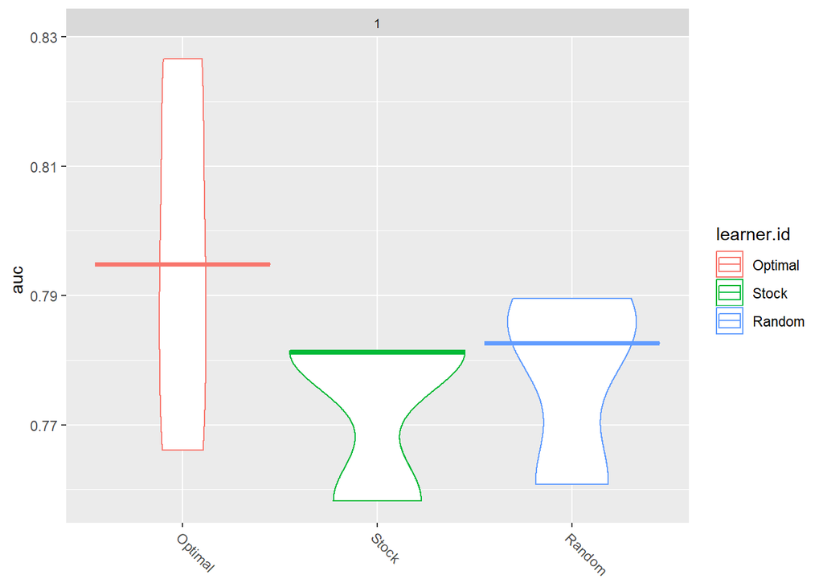

```r
plotBMRBoxplots(bmr, measure = auc, pretty.names = FALSE, style = "violin",
  order.lrn = getBMRLearnerIds(bmr)) +
  aes(color = learner.id) +
  theme(strip.text.x = element_text(size = 8))
```

Z powyższego wykresu widać jasno różnicę w błędach, z czego można wyciągnąć wniosek, jak istotny jest odpowiedni dobór parametrów do modelu.

## 2.3 Wizualizacja drzewa

Teraz przekonamy się jak wygląda najlepsze otrzymane drzewo.

```r
stockT<-mlr::train(classif_lrn2,classif_tsk)
optimalT <- mlr::train(classif_lrn1,classif_tsk)
randomT <- mlr::train(classif_lrn3, classif_tsk)
```

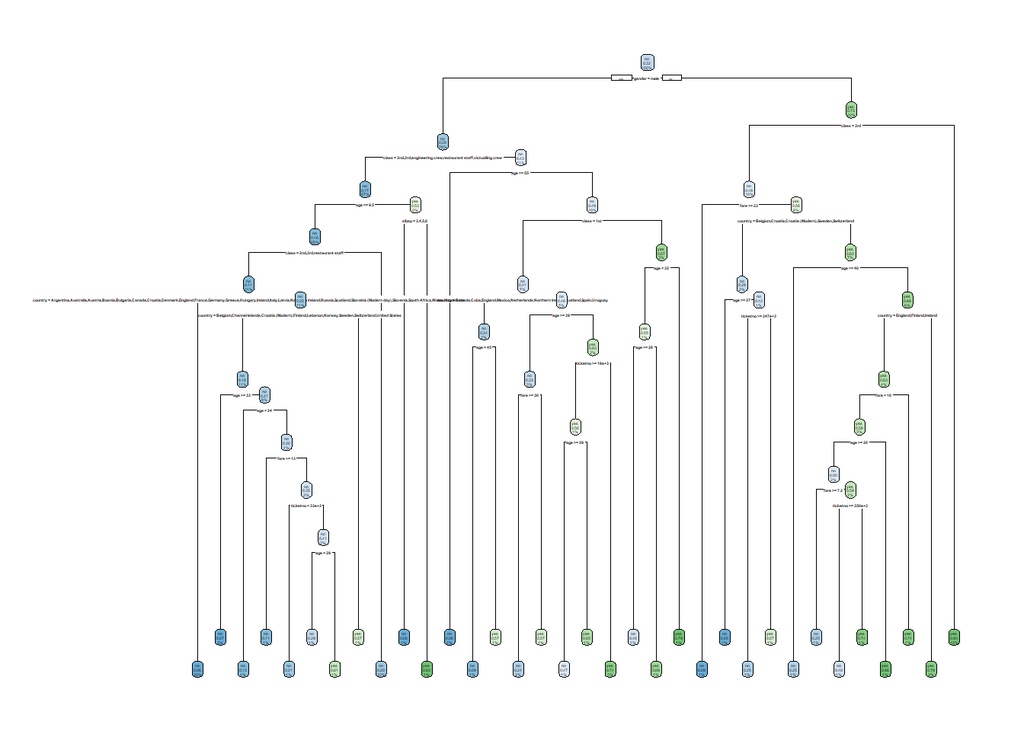

```r
rpart.plot(optimalT$learner.model)
```

Z rysunku drzewa można zauważyć, że jest dość skomplikowane i ma wiele rozgałęzień, przez co ciężko odczytać, jaki kryteria wykorzystywał model do podejmowania decyzyji. Z tego powodu przeanalizujemy teraz drzewo z domyślnymi parametrami.

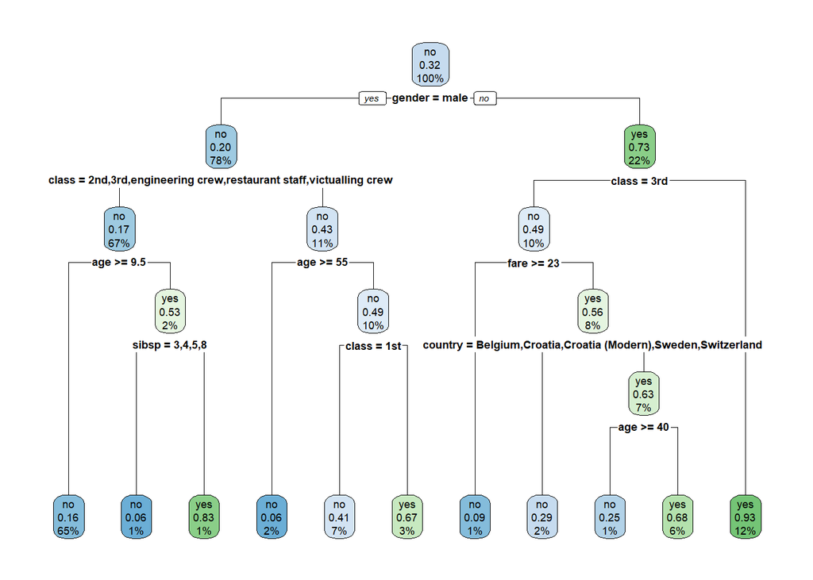

```r
rpart.plot(stockT$learner.model)
```

Tym razem dokłądnie widać, które cechy były najbardziej istotne do podziału. Można zauważyć już w pierwszym rozgałęzieniu, jak bardzo istotna jest płeć. Widać również sporą różnicę przy podziale wieku na mniejszy od 9.5 i większy od 55. Można również zauważyć istotę klasy, którą podróżował pasażer.

## 2.4 Wizualizacja różnicy kryterium podziału

Teraz sprawdzimy jak bardzo różnie będą wyglądały drzewa, które przyjmują za swoje kryterium podziału maksymalizację odpowiednio **Information Gain** i indeksu **Gini**. Testy będziemy wykonywać również na drzewach z resztę parametrów domyślną, a by można było dokładniej przeanalizować przebieg decyzji.

### 2.4.1 Information Gain

```r
classif_lrn1a <- makeLearner(id="Information Gain", cl = "classif.rpart", predict.type="prob", par.vals = list( parms = list(split = 'information')))
classif_lrn1b <- makeLearner(id="Gini Index", cl = "classif.rpart", predict.type="prob", par.vals = list( parms = list(split = 'gini')))
optimalTa <- mlr::train(classif_lrn1a,classif_tsk)
optimalTb <- mlr::train(classif_lrn1b,classif_tsk)
```

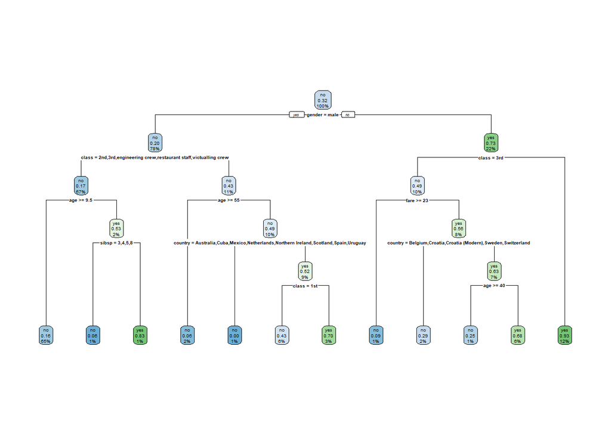

```r
rpart.plot(optimalTa$learner.model)
```

### 2.4.2 Gini Index

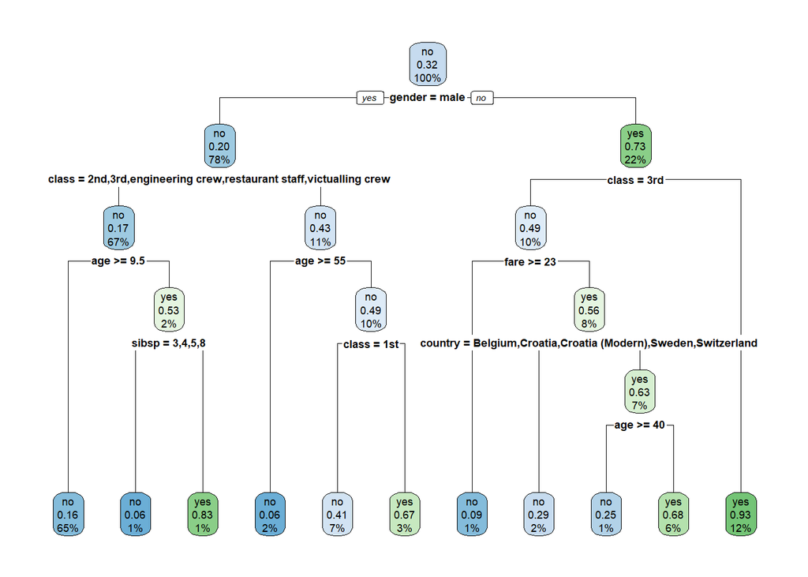

```r
rpart.plot(optimalTb$learner.model)
```

Można zauważyć, że do trzeciego poziomu rozgałęzień oba drzewa działają identycznie. Potem jednak drzewo oparte na Information Gain ma trochę inną lewą odnogę, w której zostało dodane dodatkowe rozgałęzienie określające kraj pochodzenia osób. Drzewo oparte na Information Gain okazało się więc bardziej skomplikowane, jednak czy również bardziej efektywne?

```r
bmr2 <- benchmark(learners = list(classif_lrn1a,classif_lrn1b), tasks = classif_tsk, resamplings = cv, measures = list(auc,acc,brier))
```

```r
bmr2
```

```
##   task.id       learner.id auc.test.mean acc.test.mean brier.test.mean
## 1       1 Information Gain     0.7449593     0.7956466       0.1562376
## 2       1       Gini Index     0.7646246     0.7942898       0.1539495
```

Można zauważyć jednak, że AUC okazało się lepsze dla “prostszego” drzewa opartego o Gini Index.

# 3 Podsumowanie